# Homework 4

## Submission Instructions

- Please submit your responses either as a well organized notebook (.ipynb) file.
- For questions that require calculations:
  - Show your work (i.e., show the R code you used to answer the question).
  - Make sure all the code you used to answer the question has been run (i.e., displays an output). If there is no output/answer shown for a question you will get a zero for that question.
  - Unless stated otherwise, round all *answers* to 3 decimal places.
    - Note: there should be no rounding inside the calculations you do.
  - For ease of reading, avoid showing the outputs of unnecessary values. Just show outputs of the final result.
  - Do not use trimmed tests unless specified by the question.

## Question 1:

### Using the data set **AllTimeMovies.csv**, calculate a 95% confidence interval on the trimmed mean for the movies’ domestic (US) gross. Use 20% trimming.

```r
library(WRS2)
movies = read.csv("../Data/AllTimeMovies.csv")

#Sample Size
N <- length(movies$Gross)

#Amount of Trimming
G <- 0.2

#Trimmed mean
M <- mean(movies$Gross, tr = G)

#Winsorized Variance and Standard Deviation
var <- winvar(movies$Gross, tr = G)
s <- sqrt(var)

#Standard Error of Trimmed Mean
SE <- s / ((1-2*G) * sqrt(N))

#Degrees of Freedom
h <- N - 2 * floor(G * N)
df <- h - 1

#Critical T
alpha <- 0.05
t_crit <- qt(alpha/2, df = df, lower.tail = FALSE)

bottom <- M - t_crit * SE
top <- M + t_crit * SE
```

```
## [1] "[204.341, 235.782]"
```

## Question 2:

### Using the movie data from the previous question, test $H_0: \mu = 240.19$ using 20% trimmed means.

### Make sure to report:

- the test statistic
- degrees of freedom
- p-value
- whether your reject or fail to reject the $H_0$

```r
mu <- 240.19
t <- (M - mu) / SE

p <- pt(t, df = df) * 2
```

```
## [1] "Test statistic: -2.574"
```

```
## [1] "df = 48"
```

```
## [1] "p = 0.013"
```

```
## [1] "Since p < .05 we reject the null hypothesis."
```

## Question 3:

### A company claims that on average, when exposed to its toothpaste, 45% of all bacteria related to gingivitis is killed. You run 10 tests and find that the percentages of bacteria killed among these tests are

# $$38, 44, 62, 72, 43, 40, 43, 42, 39, 41$$

### Assuming the data comes from a normally distributed population, test the hypothesis that the average percentage is 45 with $\alpha = 0.01$. Calculate both a p-value and a confidence interval. Assume observations are randomly sampled from a normal distribution. Use of `t.test()` is not permitted.

### Make sure to report:

- the test statistic
- degrees of freedom
- Confidence interval
- p-value
- whether your reject or fail to reject the $H_0$

```r
data = c(38,44,62,72,43,40,43,42,39,41)

M <- mean(data)
s <- sd(data)
N <- length(data)
se <- s/sqrt(N)

#Degrees of Freedom
df <- N - 1

#Critical T-value (note: .01 needs to be divided by 2 because it is a two tailed test)
alpha <- 0.01
T_crit <- qt(alpha/2, df = df, lower.tail = FALSE)

#Test statistic
t <- (M - 45)/se

#P-value
p <- pt(t, df = df, lower.tail = FALSE) * 2

#99% Confidence Interval
CI_bottom <- M - T_crit * se
CI_top <- M + T_crit * se
```

```
## [1] "Test statistic: 0.393"
```

```
## [1] "df = 9"
```

```
## [1] "99% CI =  [ 34.822 ,  57.978 ]"
```

```
## [1] "p = : 0.703"
```

```
## [1] "Since p > .05 we fail to reject"
```

## Question 4:

### Use the R function `t.test()` to calculate the previous question’s answer. Hint, R’s `help()` documentation is useful here.

```r
t.test(data, mu = 45, alternative = c("two.sided"), conf.level = .99)
```

```
##
##  One Sample t-test
##
## data:  data
## t = 0.39295, df = 9, p-value = 0.7035
## alternative hypothesis: true mean is not equal to 45
## 99 percent confidence interval:
##  34.82158 57.97842
## sample estimates:
## mean of x
##      46.4
```

## Question 5:

### Recalculate the p-value for the previous question with the hypothesis $H_0: \mu > 45$. Do not use `t.test()`.

```r
p <- pt(t, df = df)
round(p, 3)
```

```
## [1] 0.648
```

## Question 6:

### Use the R function `t.test()` to calculate the previous question’s result (i.e., use it to test $H_0: \mu > 45$).

```r
t.test(data, mu = 45, alternative = c("less"), conf.level = .99)
```

```
##
##  One Sample t-test
##
## data:  data
## t = 0.39295, df = 9, p-value = 0.6483
## alternative hypothesis: true mean is less than 45
## 99 percent confidence interval:
##      -Inf 56.45214
## sample estimates:
## mean of x
##      46.4
```

## Question 7:

### Some archaeologists theorize that ancient Egyptians interbred with several different immigrant populations over thousands of years. To see if there is any indication of changes in body structure that might have resulted, they measured 30 skulls of male Egyptians dated from 4000 B.C.E. and 30 others dated from 200 B.C.E.

- Thomson and Randall-Maciver, *Ancient Races of the Thebaid*, Oxford: Oxford University Press, 1905.

### The data can be found in **“SkullsPartial.csv”**. The column “mb” measures the maximal breadth of the skull.

### The data is in the “tidy format”. Find a way to calculate the means for both epochs, as well as the difference between the means. *No special packages are required for this*. You have already learned methods which can help you here.

> *There are a bunch of ways to do this with tidy formatted data, here are a few simple methods. The second, third, and fourth methods are the most preferable in this instance because they work even if the data is out of order.*”

```r
skulls <- read.csv("../Data/SkullsPartial.csv")

#METHOD 1.

#You can index the values you need specifically.
# Note: if the data is not in a logical order (i.e., shuffled) this method doesn't work.

M_4000 <- mean(skulls$mb[1:30])

M_200 <- mean(skulls$mb[31:60])

M_diff <- M_4000 - M_200
```

```
## [1] "M_4000 =  131.367"
```

```
## [1] "M_200 =  135.5"
```

```
## [1] "M_diff =  -4.133"
```

```r
#METHOD 2.

# You can use the subset function, though, be aware that the subset function returns a data frame.

c4000BC <- subset(skulls, epoch == "c4000BC")
c200BC <- subset(skulls, epoch == "c200BC")

M_4000 <- mean(c4000BC$mb)
M_200 <- mean(c200BC$mb)

M_diff <- M_4000 - M_200
```

```
## [1] "M_4000 =  131.367"
```

```
## [1] "M_200 =  135.5"
```

```
## [1] "M_diff =  -4.133"
```

```r
#METHOD 3.

# You can use the subset function and pull out the column you want as a vector.

M_4000 <- mean(subset(skulls, epoch == "c4000BC")[,2])
M_200 <- mean(subset(skulls, epoch == "c200BC")[,2])

M_diff <- M_4000 - M_200
```

```
## [1] "M_4000 =  131.367"
```

```
## [1] "M_200 =  135.5"
```

```
## [1] "M_diff =  -4.133"
```

```r
#METHOD 4.

# You can use a logical statement inside your index to subset according to the grouping column "epoch".

M_4000 <- mean(skulls$mb[skulls$epoch == "c4000BC"])
M_200 <- mean(skulls$mb[skulls$epoch == "c200BC"])

M_diff <- M_4000 - M_200
```

```
## [1] "M_4000 =  131.367"
```

```
## [1] "M_200 =  135.5"
```

```
## [1] "M_diff =  -4.133"
```

Note: depending on how you subtract the group means, the mean difference will be either negative or positive.

## Question 8:

### Using the skull data, calculate the standard deviation and variance for both epochs. You are allowed to use `sd()` and `var()`.

```r
#Standard Deviation
s_4000 <- sd(skulls$mb[skulls$epoch == "c4000BC"])
s_200 <- sd(skulls$mb[skulls$epoch == "c200BC"])

#Variance
var_4000 = s_4000^2
var_200 <- s_200^2
```

```
## [1] "s_4000 =  5.129"
```

```
## [1] "var_4000 =  26.309"
```

```
## [1] "s_200 =  3.919"
```

```
## [1] "var_200 =  15.362"
```

## Question 9:

### Using the skull data, calculate the pooled variance.

```r
#Group Sample Size
n_4000 <- length(skulls$mb[skulls$epoch == "c4000BC"])
n_200 <- length(skulls$mb[skulls$epoch == "c200BC"])

#Pooled Variance
sp_sq <- ((n_4000 - 1)*var_4000 + (n_200 - 1)*var_200) / (n_4000 + n_200 - 2)
sp_sq
```

```
## [1] 20.83563
```

## Question 10:

### Using the skull data, calculate the pooled standard error.

```r
se <- sqrt(sp_sq / n_4000 + sp_sq / n_200)
se
```

```
## [1] 1.178576
```

## Question 11:

### Calculate a 95% Confidence interval for the difference in mean skull breadth between these two epochs. Use of `t.test()` is not permitted.

```r
df <- n_4000 + n_200 - 2
alpha <- 0.05
t_crit <- qt(alpha/2, df = df, lower.tail = FALSE)

lower <- M_diff - t_crit * se
upper <- M_diff + t_crit * se

paste("[", round(lower, 3), ", ", round(upper, 3), "]", sep = "")
```

```
## [1] "[-6.493, -1.774]"
```

> Note: depending on how you subtract the means, this confidence interval will either be entirely positive or entirely negative.

## Question 12:

### Test $H_0: \mu_{_\text{4000}} - \mu_{_\text{200}} = 0$. Use of `t.test()` is not permitted.

### Make sure to report:

- the test statistic
- p-value
- whether your reject or fail to reject the $H_0$

```r
mu <- 0
t <- (M_diff - mu) / se

#Since the test statistic is negative in this case (i.e., below 0), we calculate the p-value from left to right.
p <- pt(t, df = df) * 2
```

```
## [1] "Test statistic: -3.507"
```

```
## [1] "p = 0.001"
```

```
## [1] "Since p < .05 we reject the null hypothesis."
```

> Note: depending on how you subtract the means, the test statistic will be either postive or negative. This will impact the direction you need calculate your p-value.

## Question 13:

### A researcher states their null hypothesis about the skull data as $H_0: \mu_{_\text{4000}} < \mu_{_\text{200}}$.

### Another way of expressing this is by writing: $H_0: \mu_{_\text{4000}} - \mu_{_\text{200}} < 0$.

### Given the null hypothesis being expressed, answer the following questions:

#### a. Is this a one or two-tailed hypothesis?

- One-tailed

#### b. How would you interpret this hypothesis in plain English?

- The breadth of 4000 B.C.E. skulls are smaller (on average) than 200 B.C.E. skulls.

#### c. In which tail is the critical region located for this hypothesis?

- Right tail.
  - *Rationale:* Since the null hypothesis states that the difference between 4000BCE and 200BCE will be LESS than 0, you need to find a mean difference greater than 0 to falsify the claim.

#### d. Given what you said in “c.”, which direction should a p-value be calculated? *Left to right* OR *right to left*?

- Right to left

#### e. There are two other mathematically equivalent ways of writing the null hypothesis here. What are they? Your answer should take the form of “$H_0:$________”.

- $H_0: \mu_{200} - \mu_{4000} > 0$
- $H_0: \mu_{200} > \mu_{4000}$

## Question 14:

### Test $H_0: \mu_{_\text{4000}} - \mu_{_\text{200}} < 0$ or an equivalent version of it. Report the p-value and whether you reject the null hypothesis. Use of `t.test()` is not permitted.

```r
p <- pt(t, df = df, lower.tail = FALSE)
```

```
## [1] "p = 1"
```

```
## [1] "Since p > .05, we FAIL to reject the null hypothesis."
```

```
## [1] "i.e., we can't reject the claim that the 4000 B.C.E skulls are smaller on average."
```

- Note: if you subtracted the means in the opposite direction (e.g. $\mu_{200} - \mu_{4000}$) then your null hypothesis becomes $H_0: \mu_{200} - \mu_{4000} > 0$. Stated this way, the critical region is in the left tail and the p-value needs to be calculated from left to right.

## Question 15:

### Create a barplot of the means for the Skull data. Give each bar 95% confidence intervals as the errorbars. Have the y-axis go from 100 to 140.

- *Note: to solve this I am using the “manual” way of plotting. You could use ggplot’s automated functions as well.*

```r
library(ggplot2)
library(plyr)

plotData <- ddply(skulls, c("epoch"), summarise,
                  n = length(mb),
                  Mean = mean(mb),
                  df = n - 1,
                  alpha = 0.05,
                  t_crit = qt(alpha/2, df = df, lower.tail = FALSE),
                  se = sd(mb) / sqrt(n),
                  MOE = t_crit * se
            )

plotData #Note: you do not need to display this information, just providing it for reference.
```

| epoch | n | Mean | df | alpha | t_crit | se | MOE |
| --- | --- | --- | --- | --- | --- | --- | --- |
| c200BC | 30 | 135.5000 | 29 | 0.05 | 2.04523 | 0.7155899 | 1.463546 |
| c4000BC | 30 | 131.3667 | 29 | 0.05 | 2.04523 | 0.9364685 | 1.915293 |

| epoch <chr> | n <int> | Mean <dbl> | df <dbl> | alpha <dbl> | t_crit <dbl> | se <dbl> | MOE <dbl> |
| --- | --- | --- | --- | --- | --- | --- | --- |
| c200BC | 30 | 135.5000 | 29 | 0.05 | 2.04523 | 0.7155899 | 1.463546 |
| c4000BC | 30 | 131.3667 | 29 | 0.05 | 2.04523 | 0.9364685 | 1.915293 |

2 rows

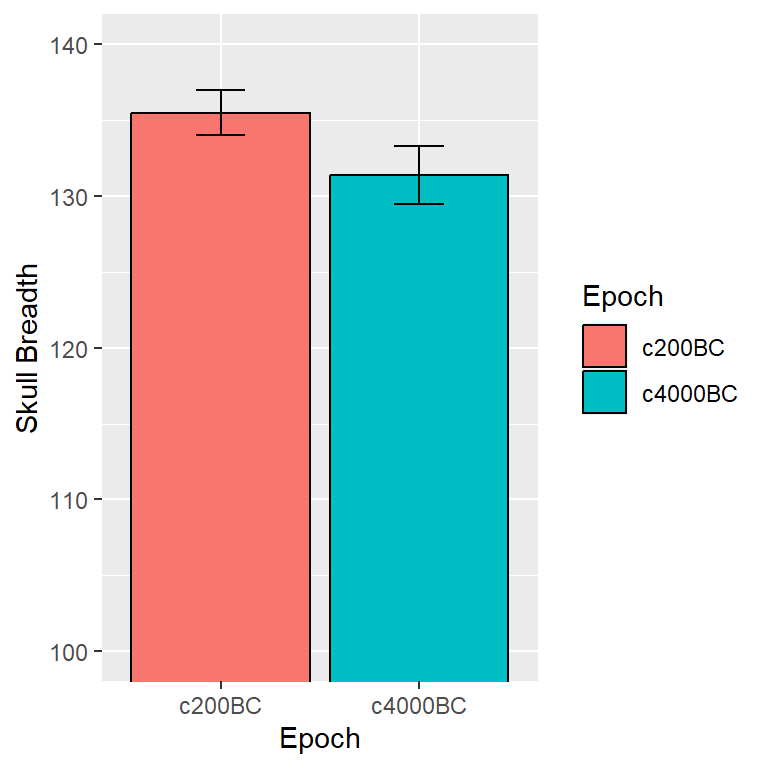

```r
ggplot(plotData, aes(x = epoch, y = Mean)) +
    geom_bar(stat = "identity",
             aes(fill = epoch),
             colour = "black") +
    geom_errorbar(aes(ymin = Mean - MOE,
                      ymax = Mean + MOE),
                      width = .25
                     ) +
  coord_cartesian(ylim = c(100, 140)) +
  xlab("Epoch") + ylab("Skull Breadth") + labs(fill = "Epoch")
```

## Question 16:

### Suppose that the summary stats of your groundbreaking research are . . .

## $\bar{x}_1 = 15$

## $\bar{x}_2 = 12$

## $s^2_1 = 8$

## $s^2_2 = 24$

## $n_1 = 20$

## $n_2 = 10$

### Verify that $s^2_p = 13.14$, $T = 2.14$, and that a classic T-test rejects the null hypothesis of equal means with $\alpha = 0.05$. Compute a confidence interval for this hypothesis test.

```r
M1 <- 15
M2 <- 12
var1 <- 8
var2 <- 24
n1 <- 20
n2 <- 10
alpha <- 0.05

#CALCULATIONS

#Pooled Variance
var_pool <- ((n1 - 1)*var1 + (n2-1)*var2) / (n1 + n2 - 2)

#Standard Error (of the Difference between groups)
se_diff <- sqrt((var_pool/n1) + (var_pool/n2))

#Test Statistic
T_stat <- ((M1 - M2) - 0) / se_diff

#Dregrees of Freedom
df <- n1 + n2 - 2

#P-Value
p <- pt(T_stat, df = df, lower.tail = FALSE) * 2

#Critical T
T_crit <- qt(alpha/2, df = df, lower.tail = FALSE)

#Confidence Interval
bottom <- (M1 - M2) - T_crit * se_diff
top <- (M1 - M2) + T_crit * se_diff
```

```r
#Pooled Variance
round(var_pool, 2)
```

```
## [1] 13.14
```

```r
#Test Statistic
round(T_stat, 2)
```

```
## [1] 2.14
```

```r
#P-Value
round(p, 3)
```

```
## [1] 0.042
```

```
## [1] "The pooled variance and the test statistic are both correct and the classic t-test rejects the hypothesis of equal means."
```

```
## [1] "95% CI [0.124, 5.876]"
```

## Question 17:

### Using the information from the previous question, plot the group means and their respective confidence intervals. Label the two groups A and B.

- Hint: To do this you will need to make a dataframe with the relevant values. Note that we don’t have the original data so you can’t use ggplot’s automated method or the `ddply()` function. You must build your own dataframe with the info you have (it’s actually a lot easier than it sounds - think about the early lectures we did with R talking about dataframes).

```r
#Getting values for the plot's dataframe
Group <- c("A", "B")
Mean <- c(M1, M2)
n <- c(n1, n2)
df <- n - 1
sd <- c(sqrt(var1), sqrt(var2))
se <- sd/sqrt(n)
alpha <- 0.05
T_crit <- qt(alpha/2, df = df, lower.tail = FALSE)
MOE <- se * T_crit

plotData <- data.frame(Group, Mean, MOE)
print(plotData)
```

```
##   Group Mean      MOE
## 1     A   15 1.323745
## 2     B   12 3.504519
```

```r
#Note it is not necessary to print the dataframe.  I just did it to show you guys the values I got.
```

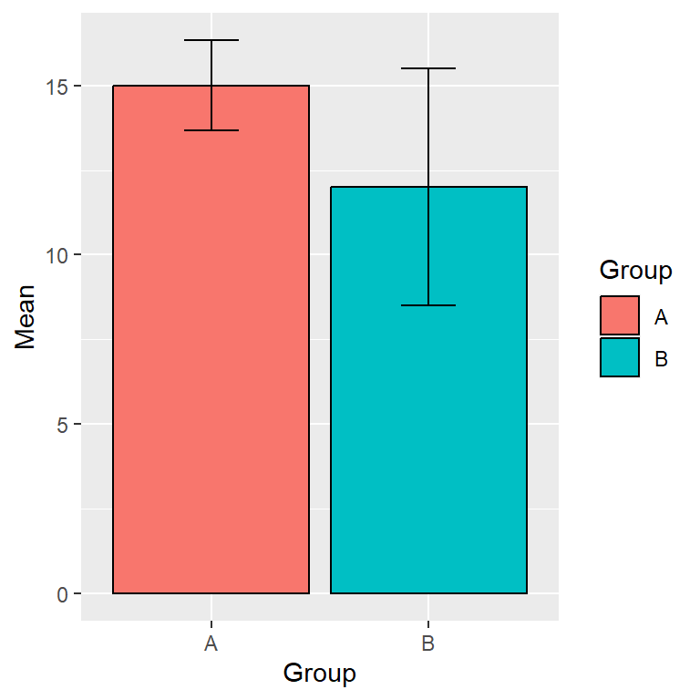

```r
library(ggplot2)

ggplot(plotData, aes(x = Group, y = Mean, fill = Group)) +
    geom_bar(stat = "identity", colour = "black") +
    geom_errorbar(aes(ymin = Mean - MOE,
                      ymax = Mean + MOE),
                      width = .25
                     )
```

## Question 18:

### What is a potentially serious problem for the results seen in the previous question (hint: compare the errorbars)?

> The spread are quite different meaning that the homogeneity of variance assumption might be violated.